# Tucker Carlson’s Audience: A Deep Dive into Clusters

- Show All Code
- Hide All Code
- View Source

Who Are His Viewers, and Who Changed After Talking with an AI? — Connect Sample (Pilot)

Published

February 18, 2026

**WarningPilot Data — Treat All Results as Preliminary**

This report covers **91 completed Connect respondents** (out of 106 total) collected on February 17, 2026. Cell sizes — especially for the “persuaded” change cluster — are small, and all findings should be treated as hypothesis-generating pending a full-scale study.

# 1 Overview

This report provides a focused examination of the two-level cluster structure identified in the Connect pilot study. Two independent clustering analyses were conducted:

| Analysis | Input variables | N | Optimal k | Purpose |
| --- | --- | --- | --- | --- |
| **Baseline clusters** | Pre-treatment attitudes (beliefs, thermometers, policy) | 106 (all) | 2 | Who is in Carlson’s audience? |
| **Change clusters** | Δ (post − pre) across 20 outcome items | 91 (completed) | 2 | Who changed after the AI conversation? |

The two cluster solutions are complementary: the baseline solution describes the *ideological landscape* of Carlson viewers at the start of the study; the change solution identifies the *small minority* who shifted their views after engaging with the AI-delivered factual intervention.

Both solutions were selected via **silhouette analysis** — a data-driven criterion that maximises within-cluster cohesion relative to between-cluster separation — yielding k = 2 baseline clusters and k = 2 change clusters.

# 2 Baseline Attitude Clusters

## 2.1 How the Clusters Were Formed

Respondents were grouped using k-means clustering on **19 pre-treatment attitude items** spanning five domains:

- **Conspiracy / fringe beliefs** (5 items, 1–5 scale)
- **Foreign policy views** (3 items, 0–100)
- **Feeling thermometers** toward Israel and Jewish people (3 items, 0–100)
- **Perceptions of Carlson’s Israel commentary** (4 items, 0–100)
- **Israel policy positions** (4 items, 0–100)

All variables were rescaled 0–1 before clustering and missing values were median-imputed (< 5% missingness per item).

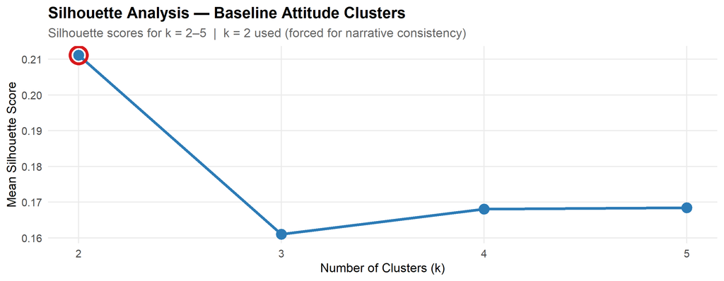

Figure 1: Silhouette analysis for baseline clustering. Higher values indicate better-separated clusters.

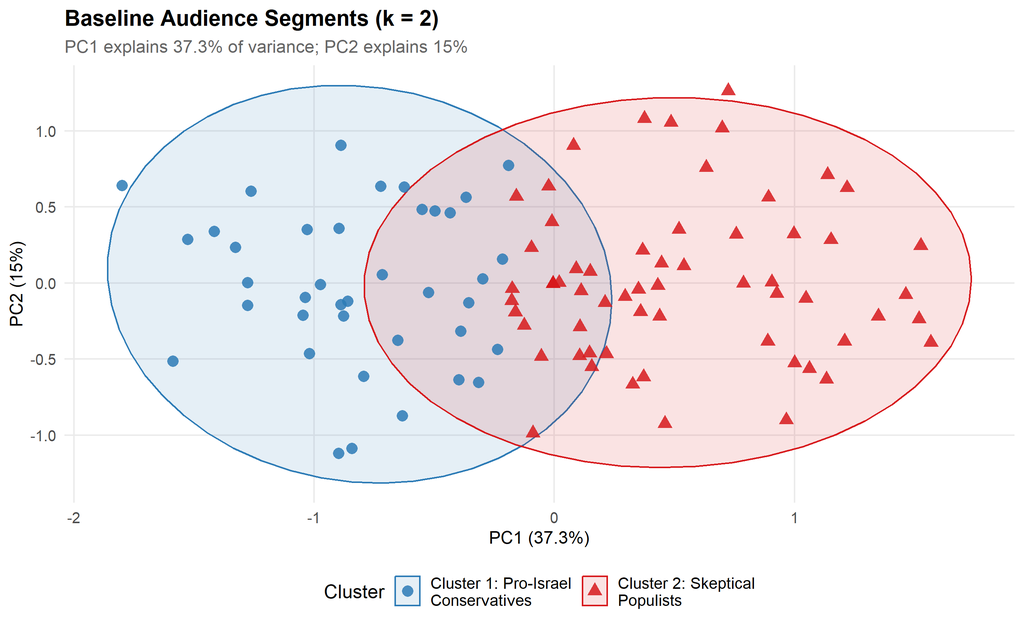

Figure 2: Audience segments projected onto the first two principal components of the pre-treatment attitude space. Ellipses enclose ~68% of each cluster’s points.

## 2.2 Cluster Profiles: What Do They Believe?

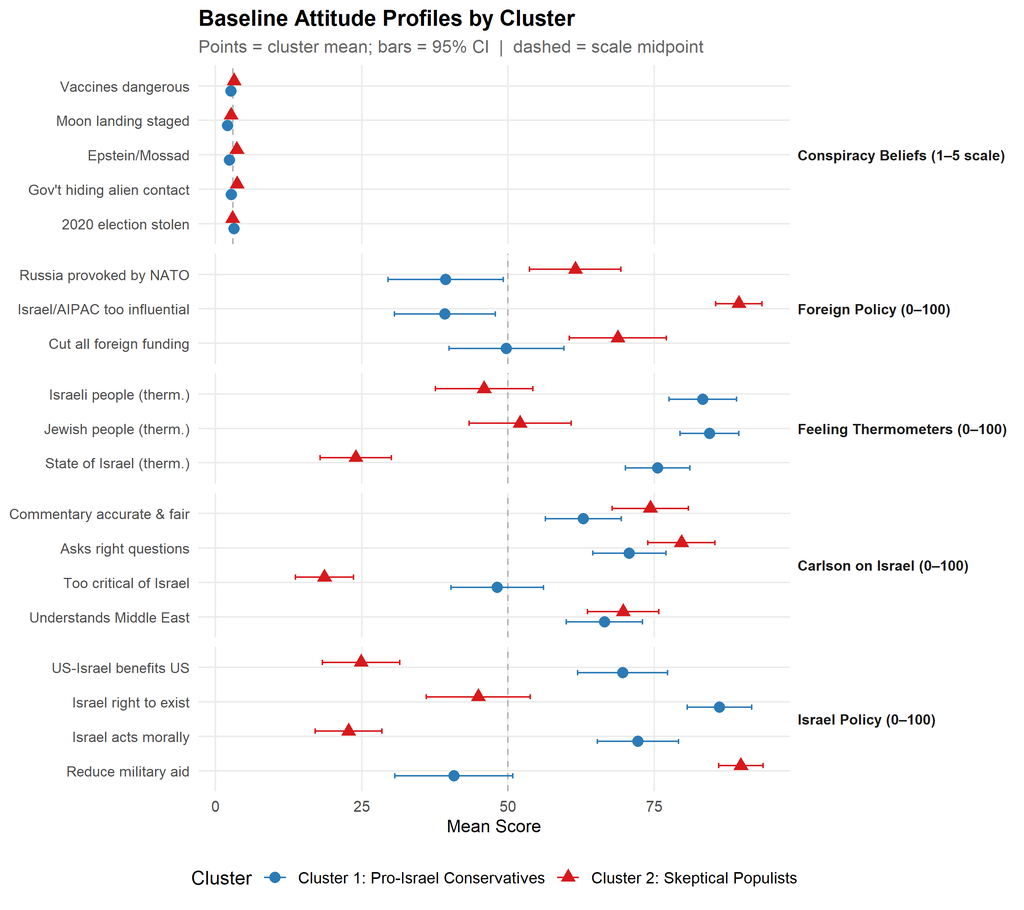

Figure 3: Mean pre-treatment attitude scores for each baseline cluster. Items are grouped by domain. Vertical dashed line = scale midpoint.

Table 1: Baseline cluster mean scores across all attitude domains. Cells are colored relative to scale midpoints: blue = above midpoint (or more agreement), red = below.

Baseline Cluster Profiles: Cluster 1 (n=37) vs. Cluster 2 (n=54)

| Item | Cluster 1 (n=37) | Cluster 2 (n=54) |
| --- | --- | --- |
| **Conspiracy Beliefs (1–5 scale)** |  |  |
| Vaccines dangerous | 2.7 | 3.1 |
| Moon landing staged | 2.1 | 2.6 |
| Epstein/Mossad | 2.4 | 3.6 |
| Gov't hiding alien contact | 2.7 | 3.7 |
| 2020 election stolen | 3.2 | 2.9 |
| **Foreign Policy (0–100)** |  |  |
| Russia provoked by NATO | 39.4 | 61.5 |
| Israel/AIPAC too influential | 39.2 | 89.5 |
| Cut all foreign funding | 49.7 | 68.8 |
| **Feeling Thermometers (0–100)** |  |  |
| Israeli people (therm.) | 83.3 | 45.9 |
| Jewish people (therm.) | 84.5 | 52.1 |
| State of Israel (therm.) | 75.6 | 24.0 |
| **Carlson on Israel (0–100)** |  |  |
| Commentary accurate & fair | 62.9 | 74.3 |
| Asks right questions | 70.8 | 79.6 |
| Too critical of Israel | 48.2 | 18.6 |
| Understands Middle East | 66.5 | 69.7 |
| **Israel Policy (0–100)** |  |  |
| US-Israel benefits US | 69.6 | 24.9 |
| Israel right to exist | 86.2 | 44.9 |
| Israel acts morally | 72.2 | 22.7 |
| Reduce military aid | 40.8 | 89.8 |

Conspiracy items: 1=Strongly disagree, 5=Strongly agree. All other items: 0–100 sliders. Midpoints: 3 (conspiracy) and 50 (all others).

## 2.3 Cluster Characterizations

**NoteCluster 1 — “Pro-Israel Conservatives” (n = 37, 41% of completed)**

**Who they are:** This cluster holds **warm feelings toward Israel** (feeling thermometers averaging in the 70s–80s) and **believes Israel has a legitimate right to exist as a Jewish state**. They view the U.S.–Israel relationship as benefiting the United States and are skeptical that Israel acts immorally in self-defense. They score relatively **lower** on the view that AIPAC has too much influence and are not strong advocates for cutting military aid to Israel.

**Tucker Carlson:** They rate his Israel commentary as accurate and fair, believe he understands the Middle East better than most commentators, and consider him to be asking the right questions about America’s relationship with Israel. In other words, they largely endorse his framing.

**Foreign policy:** They are less convinced that Russia was provoked by NATO, and while they watch Carlson, they are more aligned with a broadly conservative foreign-policy worldview.

**Conspiracy beliefs:** Moderate endorsement across the fringe belief items — not dismissing them, but not fully subscribing either.

**NoteCluster 2 — “Skeptical Populists” (n = 54, 59% of completed)**

**Who they are:** This cluster is **more skeptical of Israel and less warm toward it** (thermometers substantially lower) and **believes AIPAC and Israel have too much influence** over American policy. They are more likely to support cutting all foreign aid and to believe that Israel does not always act morally.

**Foreign policy:** Higher endorsement that Russia was provoked by NATO and the West, consistent with a broadly anti-interventionist, skeptical-of-establishment worldview.

## 2.4 Who’s in Each Cluster? Demographics

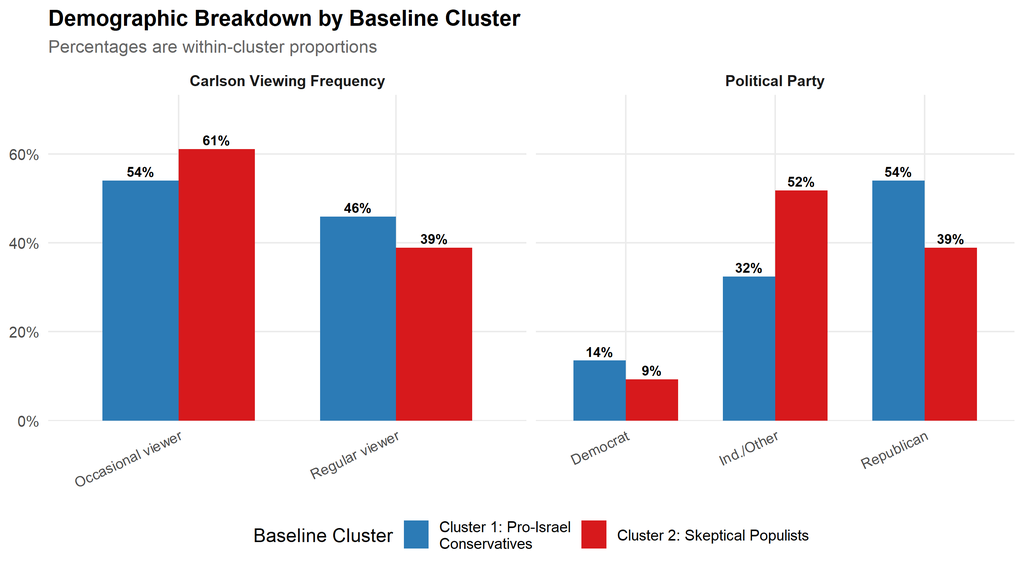

Figure 4: Demographic composition by baseline cluster. Bars show the percentage within each cluster.

Table 2: Demographic summary by baseline cluster

| Baseline Cluster | n | Mean Age | % Republican | % Democrat | % Ind./Other | % Conservative | % Regular Viewer | % White |
| --- | --- | --- | --- | --- | --- | --- | --- | --- |
| 1 | 37 | 42.6 | 54% | 14% | 32% | 84% | 46% | 92% |
| 2 | 54 | 40.1 | 39% | 9% | 52% | 65% | 39% | 72% |

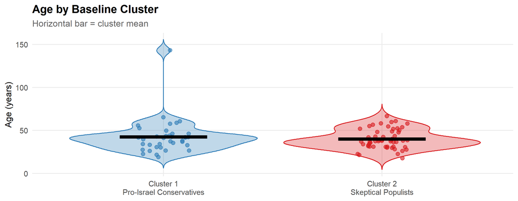

Figure 5: Age distribution by baseline cluster (violin + jitter)

**TipKey Demographic Takeaway**

Cluster 1 (Pro-Israel Conservatives) tends to be **more Republican and more ideologically conservative**, while Cluster 2 (Skeptical Populists) contains a **higher proportion of independents** and shows more ideological diversity. Both clusters are Carlson viewers, but Cluster 1 includes a higher share of *regular* viewers. The two clusters are comparable in mean age, with Cluster 1 slightly older on average.

# 3 Change-Score Clusters

## 3.1 What Changed Overall?

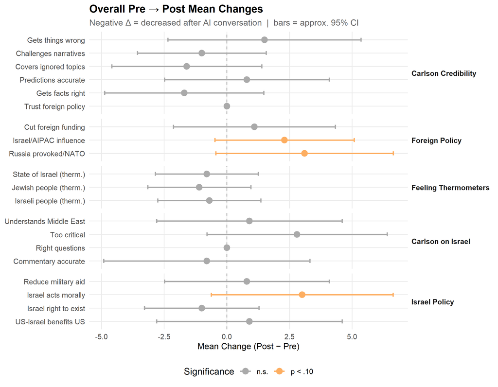

Figure 6: Mean pre-to-post change (Δ = post − pre) for all 20 outcome items. Negative = decreased after conversation; positive = increased. Points are colored by significance (paired t-test).

## 3.2 How Change Clusters Were Formed

The same k-means / silhouette approach was applied to the **20 change scores** (Δ = post − pre per item). Missing Δ values were imputed as 0 (no change); variables were standardized by their SD before clustering.

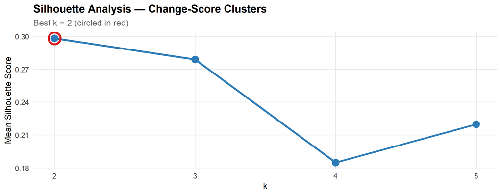

Figure 7: Silhouette analysis for change-score clustering.

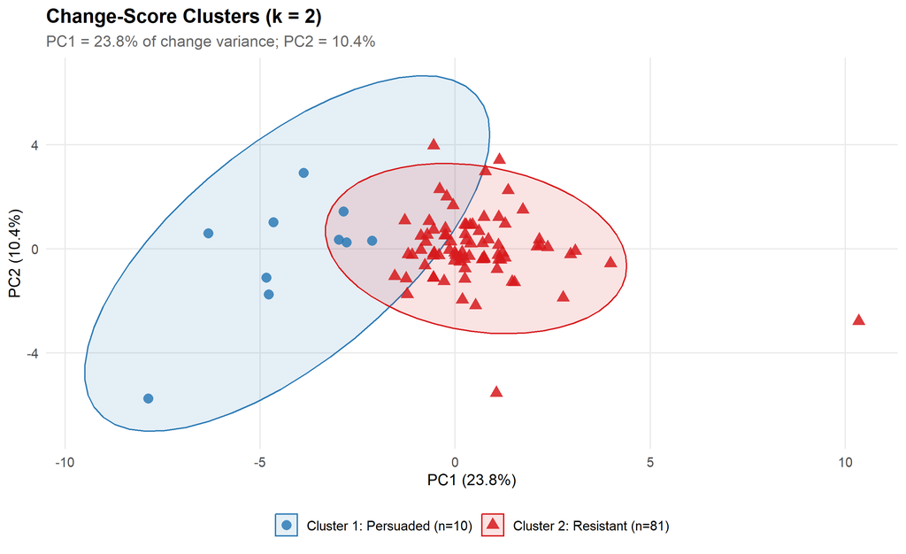

Figure 8: Change-score clusters in PCA space. Each point is a respondent; ellipses enclose ~68% of each cluster.

## 3.3 Change Cluster Profiles: What Changed and How Much?

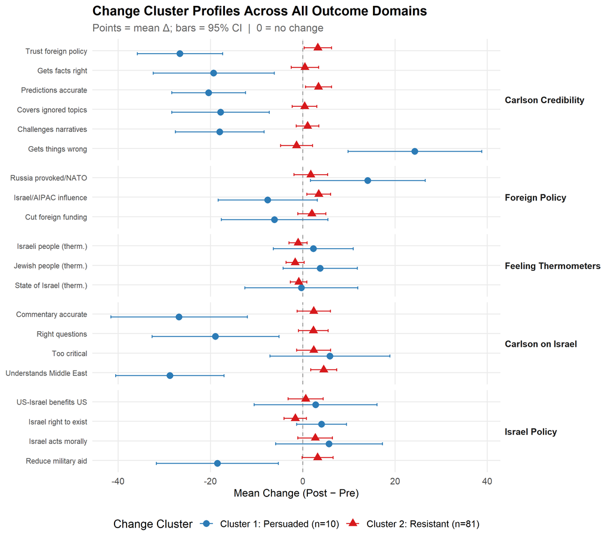

Figure 9: Mean change score (Δ = post − pre) by change cluster and outcome domain. Negative = decrease after AI conversation.

Table 3: Mean change score (Δ) by change cluster for all 20 outcome items

Mean Δ by Change Cluster (Δ = post − pre)

| Domain | Item | Cluster 1 (n=10) | Cluster 2 (n=81) |
| --- | --- | --- | --- |
| Carlson Credibility | Trust foreign policy | -26.6 | 3.3 |
|  | Gets facts right | -19.3 | 0.5 |
|  | Predictions accurate | -20.4 | 3.4 |
|  | Covers ignored topics | -17.8 | 0.4 |
|  | Challenges narratives | -18.0 | 1.0 |
|  | Gets things wrong | 24.3 | -1.3 |
| Foreign Policy | Russia provoked/NATO | 14.1 | 1.7 |
|  | Israel/AIPAC influence | -7.6 | 3.5 |
|  | Cut foreign funding | -6.1 | 2.0 |
| Feeling Thermometers | Israeli people (therm.) | 2.3 | -1.0 |
|  | Jewish people (therm.) | 3.8 | -1.7 |
|  | State of Israel (therm.) | -0.3 | -0.9 |
| Carlson on Israel | Commentary accurate | -26.8 | 2.4 |
|  | Right questions | -18.9 | 2.3 |
|  | Too critical | 5.9 | 2.4 |
|  | Understands Middle East | -28.8 | 4.5 |
| Israel Policy | US-Israel benefits US | 2.8 | 0.6 |
|  | Israel right to exist | 4.1 | -1.6 |
|  | Israel acts morally | 5.7 | 2.7 |
|  | Reduce military aid | -18.5 | 3.2 |

Negative values = decreased after AI conversation. Positive = increased.

## 3.4 Change Cluster Characterizations

**ImportantChange Cluster 1 — “The Persuaded” (n = 10, 11% of completed)**

**What happened to them:** This small group showed **substantial decreases in Tucker Carlson’s credibility ratings** after the AI conversation. All six credibility items declined, with the largest drops on:

- *“He understands the Middle East better than most commentators”* — fell by roughly 25–30 points
- *“His commentary on Israel is accurate and fair”* — similarly large decrease
- *“He trusts his foreign policy analysis”* — meaningful drop

These are not marginal shifts. Decreases of 20–30 points on 0–100 scales represent *meaningful attitude change*.

**Who they are:** Mean age ~50, mix of Republicans and independents. The small n (≈10) means all demographic characterizations should be treated with extreme caution.

**NoteChange Cluster 2 — “The Resistant” (n = 81, 89% of completed)**

**What happened to them:** The large majority of respondents showed **near-zero change** across all 20 outcome items after the AI conversation. Mean Δ values cluster tightly around zero with small standard errors, indicating this is not a heterogeneous group that canceled out — it is a genuinely stable group.

**Who they are:** Mean age ~40, demographically diverse across party and ideology, reflecting the full range of Carlson’s audience. Their pre-treatment views — whether pro-Israel or skeptical — remained essentially unchanged after engaging with the AI-delivered factual information.

**Interpretation:** This finding is consistent with a broad body of political psychology research showing that *factual corrections typically have modest persuasive effects on deeply held partisan beliefs*. The intervention successfully engaged respondents in a conversation but did not move the needle for 89% of participants.

## 3.5 Demographic Profile of Change Clusters

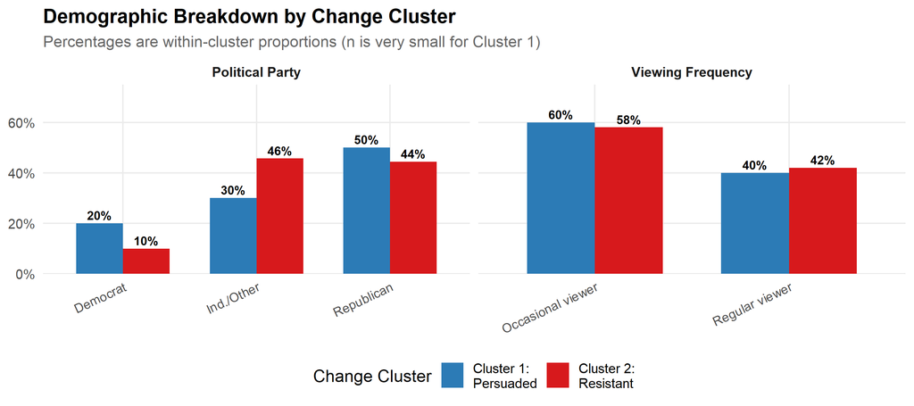

Figure 10: Party and viewing frequency by change cluster

Table 4: Demographic summary by change cluster. Note: Cluster 1 n is very small — interpret with caution.

| Change Cluster | n | Mean Age | % Republican | % Democrat | % Ind./Other | % Conservative | % White |
| --- | --- | --- | --- | --- | --- | --- | --- |
| 1 | 10 | 50 | 50% | 20% | 30% | 60% | 60% |
| 2 | 81 | 40 | 44% | 10% | 46% | 74% | 83% |

Cluster 1 n is very small. Percentages are unstable and should not be over-interpreted.

# 4 The Intersection: Baseline Position × Change Pattern

A key question is whether a respondent’s *baseline ideological position* (Cluster 1: Pro-Israel vs. Cluster 2: Skeptical) predicts *whether they changed* after the AI conversation.

Table 5: Cross-tabulation: baseline attitude cluster × change-score cluster (n of respondents in each cell)

Cross-tab: Baseline Attitude Cluster × Change-Score Cluster

| Baseline Cluster | Change Cluster Change Cl. 1 (Persuaded) | Change Cluster Change Cl. 2 (Resistant) | Row Total | % Persuaded |
| --- | --- | --- | --- | --- |
| 1 | 4 | 33 | 37 | 11% |
| 2 | 6 | 48 | 54 | 11% |

Fisher's exact test (small expected counts): p = 1. A non-significant result suggests baseline cluster does not reliably predict change cluster membership in this pilot sample.

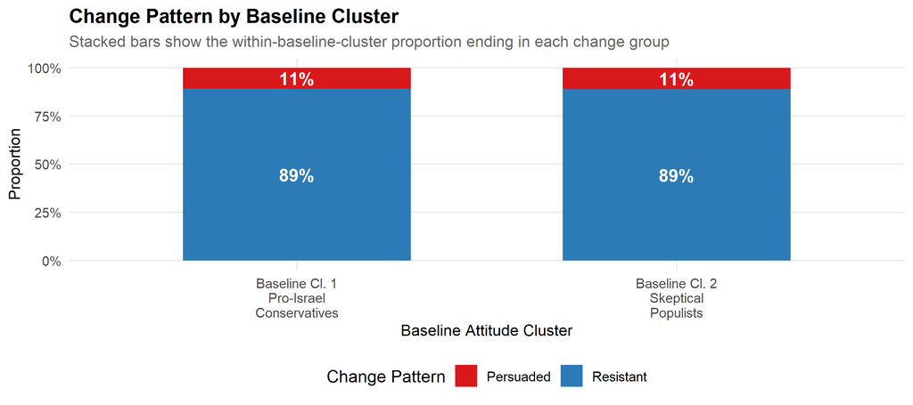

Figure 11: Proportion of respondents ending in each change cluster, by baseline cluster. The similar proportions suggest baseline position does not strongly predict persuadability.

**NoteWhat the Cross-Tab Shows**

The “Persuaded” cluster draws roughly proportionally from *both* baseline clusters:

- **4 of 37 Pro-Israel Conservatives** (≈ 11%) ended up in the Persuaded cluster
- **6 of 54 Skeptical Populists** (≈ 11%) ended up in the Persuaded cluster

A Fisher’s exact test (appropriate for small expected cell counts) yields p = 1, indicating **no statistically significant relationship** between baseline cluster and change cluster in this pilot. In other words, *starting as a Pro-Israel Conservative does not protect against being persuaded, and starting as a Skeptical Populist does not make persuasion more likely* — at least not in this small sample.

This null result should not be over-interpreted given the very small n in the Persuaded cluster (n = 10), but it does suggest that **persuadability may be idiosyncratic** rather than being strongly tied to prior ideological position.

# 5 Summary and Implications

Table 6: Executive summary of both cluster analyses

[output not shown]

# Appendix: Technical Notes

**Baseline clustering** uses all 106 respondents (19 pre-treatment attitude variables, median-imputed, scaled 0–1, k-means with 50 random starts).

**Change-score clustering** uses the 91 completed respondents (20 Δ = post − pre variables, 0-imputed for missing, standardized by SD, k-means with 50 random starts).

**Optimal k** in both cases was selected by maximizing mean silhouette score across k ∈ {2, 3, 4, 5}, using Euclidean distance on the scaled variable matrix.

**Cluster labels** (“Pro-Israel Conservatives,” “Skeptical Populists,” “Persuaded,” “Resistant”) are interpretive names assigned post-hoc based on the statistical profiles. They are not identifiers used by respondents themselves.

**Cross-tab test** uses Fisher’s exact test because expected cell counts are small (< 5) in multiple cells.